# Title

“Decoding the Brain: Linking Neural Signals to Behavioral Feedback”

# Abstract

# Section 1 Introduction

In this project, I want to build a predictive model to identify outcomes from each trial. The data set I used is a subset of data collected by Steinmetz et al. (2019) There are 18 sessions in this sub-data set. In order to know the data set, the first thing I need to do is the exploratory data analysis. In this section, I need to describe the whole structure of the data. Then I would assess the difference in a single trial or session. Second, I would do a data integration. By doing so I can tell the association across different trials or sessions. The last part of this project is the Model Training and the Prediction. In this section, I need to choose a model which is good fit to the data set and use the model to perform the test on other data set besides the 18 sessions.

# Section 2 Exploratory analysis

Table: Summary of key findings.

| mouse_name | date_exp | n_brain_area | n_neurons | n_trials | success_rate |
| --- | --- | --- | --- | --- | --- |
| Cori | 2016-12-14 | 8 | 734 | 114 | 0.61 |
| Cori | 2016-12-17 | 5 | 1070 | 251 | 0.63 |
| Cori | 2016-12-18 | 11 | 619 | 228 | 0.66 |
| Forssmann | 2017-11-01 | 11 | 1769 | 249 | 0.67 |
| Forssmann | 2017-11-02 | 10 | 1077 | 254 | 0.66 |
| Forssmann | 2017-11-04 | 5 | 1169 | 290 | 0.74 |
| Forssmann | 2017-11-05 | 8 | 584 | 252 | 0.67 |
| Hench | 2017-06-15 | 15 | 1157 | 250 | 0.64 |
| Hench | 2017-06-16 | 12 | 788 | 372 | 0.69 |
| Hench | 2017-06-17 | 13 | 1172 | 447 | 0.62 |
| Hench | 2017-06-18 | 6 | 857 | 342 | 0.80 |
| Lederberg | 2017-12-05 | 12 | 698 | 340 | 0.74 |
| Lederberg | 2017-12-06 | 15 | 983 | 300 | 0.80 |
| Lederberg | 2017-12-07 | 10 | 756 | 268 | 0.69 |
| Lederberg | 2017-12-08 | 8 | 743 | 404 | 0.76 |
| Lederberg | 2017-12-09 | 6 | 474 | 280 | 0.72 |
| Lederberg | 2017-12-10 | 6 | 565 | 224 | 0.83 |
| Lederberg | 2017-12-11 | 10 | 1090 | 216 | 0.81 |

The table summarizes the essential data structures across sessions.

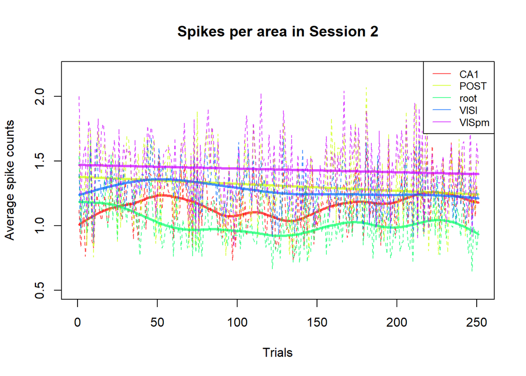

Figure: Visualization of data.

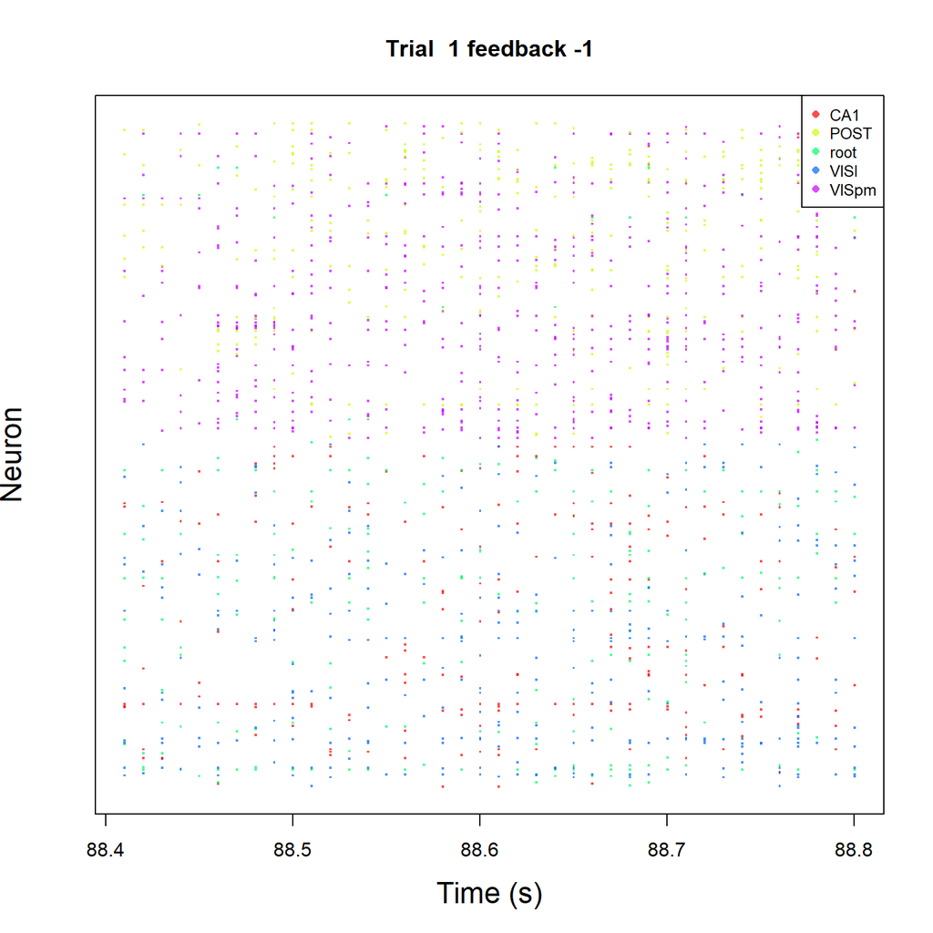

Figure: Visualization of data.

This plot represents the neural spiking activity for Trial 1 with incorrect response. And each of the dot represents a spike event. The y-axis represents the neurons; and the x-axis represents the spike time.

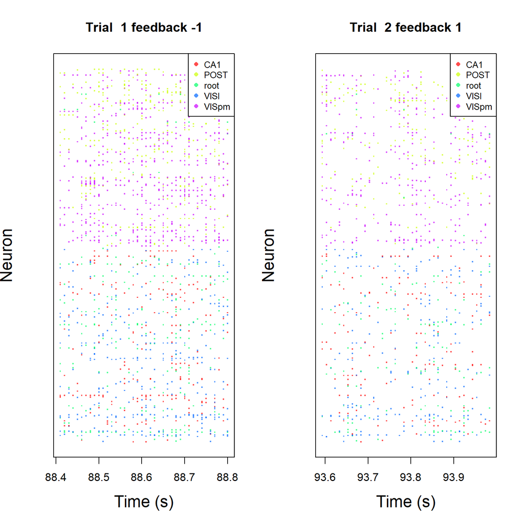

Figure: Visualization of data.

This figure compares neural spiking activity for two trials: Left panel: Trial 1, feedback = -1 Right panel: Trial 2, feedback = 1 The general spike density appears similar between the two trials. However, there are some differences in firing timing and clustering across neurons.

# Section 3 Data integration

|  | session_num | mouse_name | contrast_difference | feedback_type | avg_spike_rate |
| --- | --- | --- | --- | --- | --- |
| 1 | 1 | Cori | -0.5 | 1 | 0.03954359673024523 |
| 2 | 1 | Cori | 0 | 1 | 0.03279972752043597 |
| 3 | 1 | Cori | -0.5 | -1 | 0.04611716621253406 |
| 4 | 1 | Cori | 0 | -1 | 0.03453678474114441 |
| 5 | 1 | Cori | 0 | -1 | 0.0356267029972752 |
| 6 | 1 | Cori | 0 | 1 | 0.02735013623978201 |
| 7 | 1 | Cori | 0.5 | 1 | 0.05255449591280654 |
| 8 | 1 | Cori | 0.5 | 1 | 0.04260899182561308 |
| 9 | 1 | Cori | 0 | 1 | 0.03773841961852861 |
| 10 | 1 | Cori | 0.25 | 1 | 0.04329019073569482 |

[output cut: 5071 more lines]

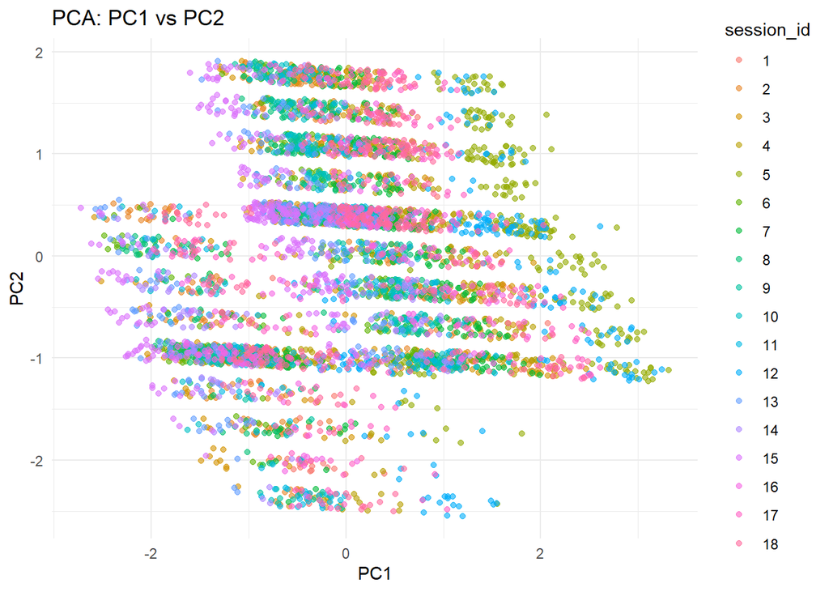

Figure: Visualization of data.

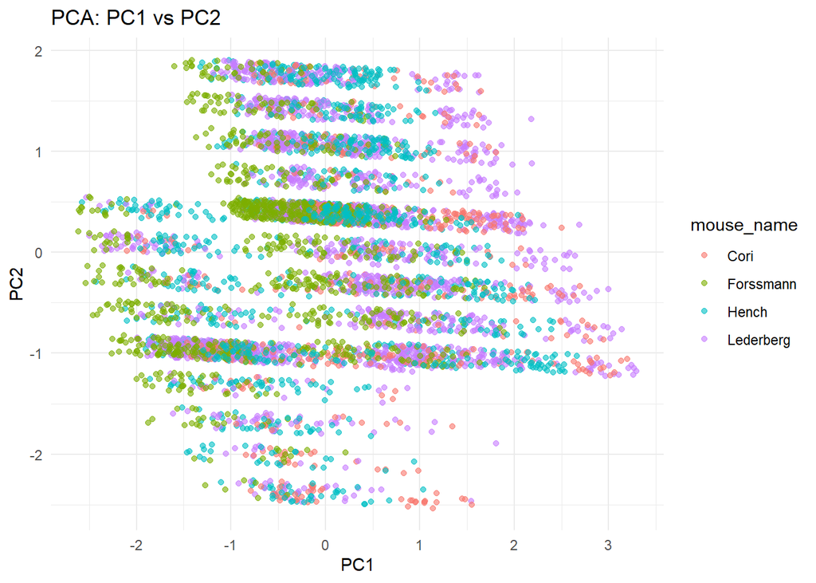

Figure: Visualization of data.

There is some difference between sessions and mouses, but it’s not the primary reason for this differences.

# Section 4 Predictive modeling

For simplicity, we fit a logistic regrssion to do the prediction.

The prediction error on the test data set is about 22%.

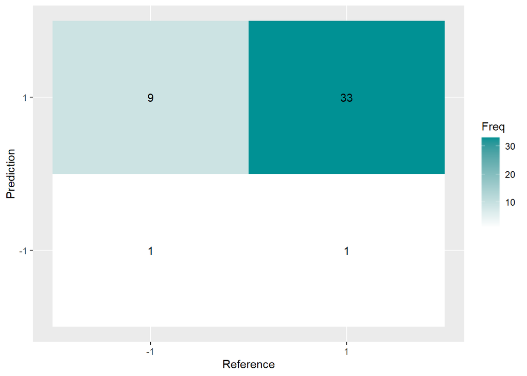

Figure: Visualization of data.

In this confusion matrix, there are 9 incorrect success predictions and 1 incorrect failure prediction. This means that the prediction is not doing well because if we just bias to success completely, we get same error rate. It may overestimates success probability and misclassifies a correct trial as incorrect.

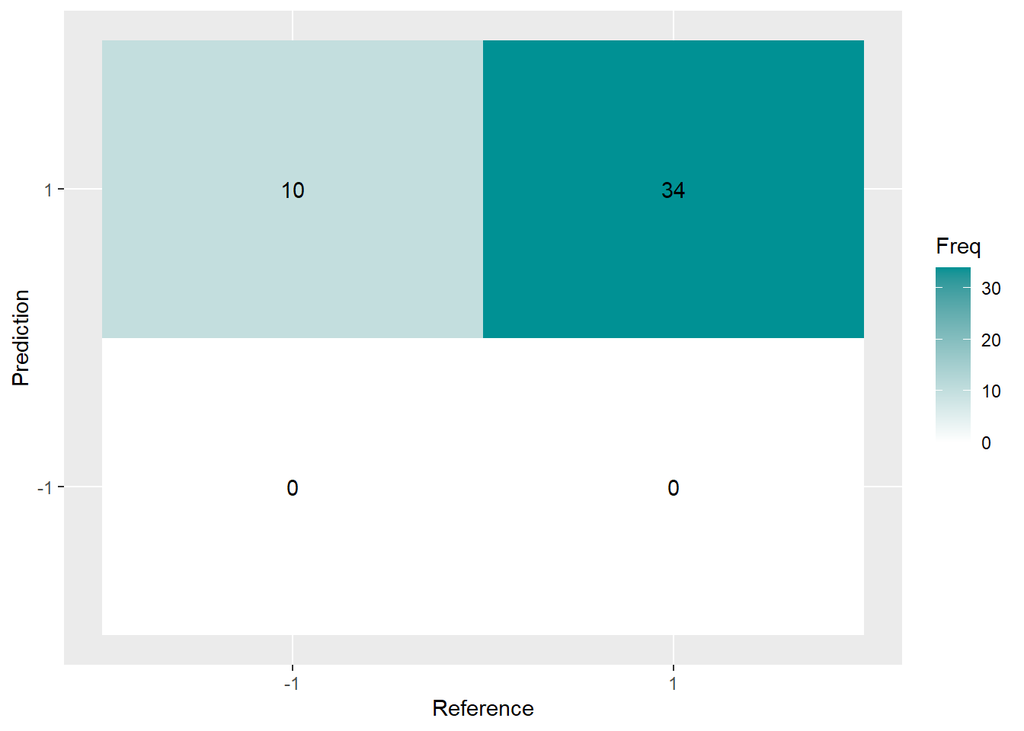

Figure: Visualization of data.

Since the majority of trials are 1, this simple rule-based model achieves the same accuracy (~77.3%) as logistic regression. This means the logistic regression model did not improve beyond naive guessing.

This logistic regression model extends the previous model by incorporating brain area-specific spike rates as additional predictors for trial success.

The prediction error on the test data set is about 25%, which is worse than the first model.

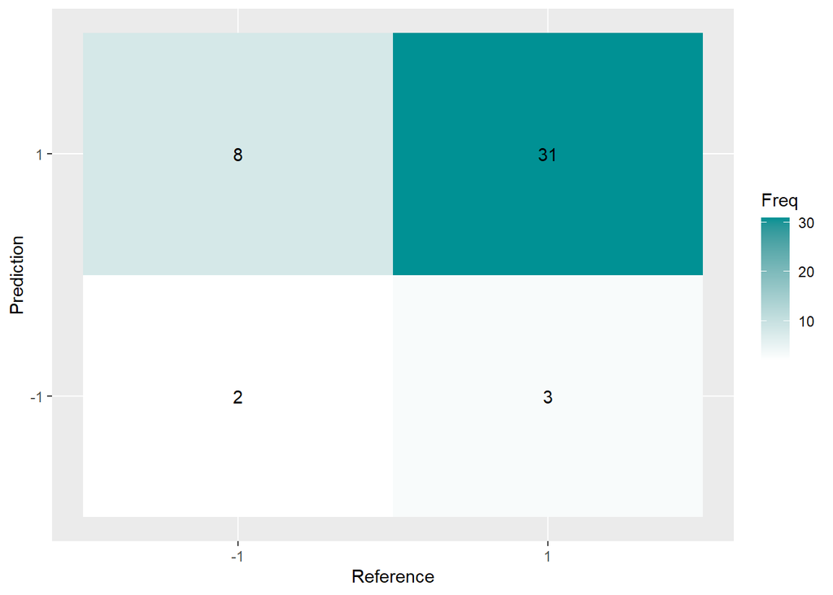

Figure: Visualization of data.

It appears that the model predicts more failures compared to the previous one. However, its performance in predicting failures is not particularly strong.

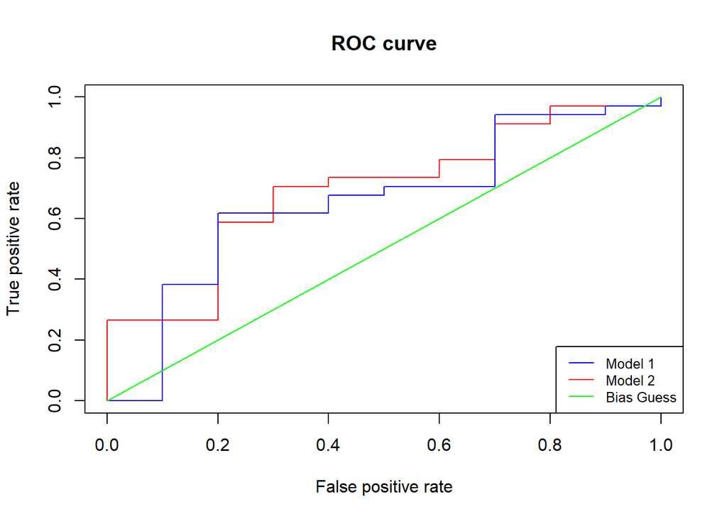

Figure: Visualization of data.

This ROC curve compares two logistic regression models (Model 1 and Model 2) along with a baseline guessing model. From the ROC curve, we see that Mode 1 and Model 2 have similiar performance.

From AUC, 0.656 < 0.694, means that Model 2 is slgithly better than Model 1. The AUC score of baseline = 0.5 means no predictive power.

# Section 5 Prediction performance on the test sets

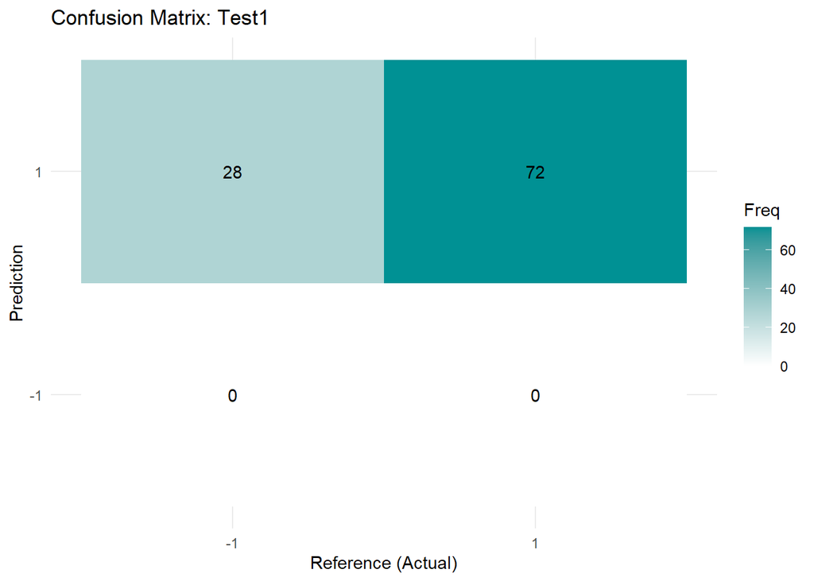

Figure: Visualization of data.

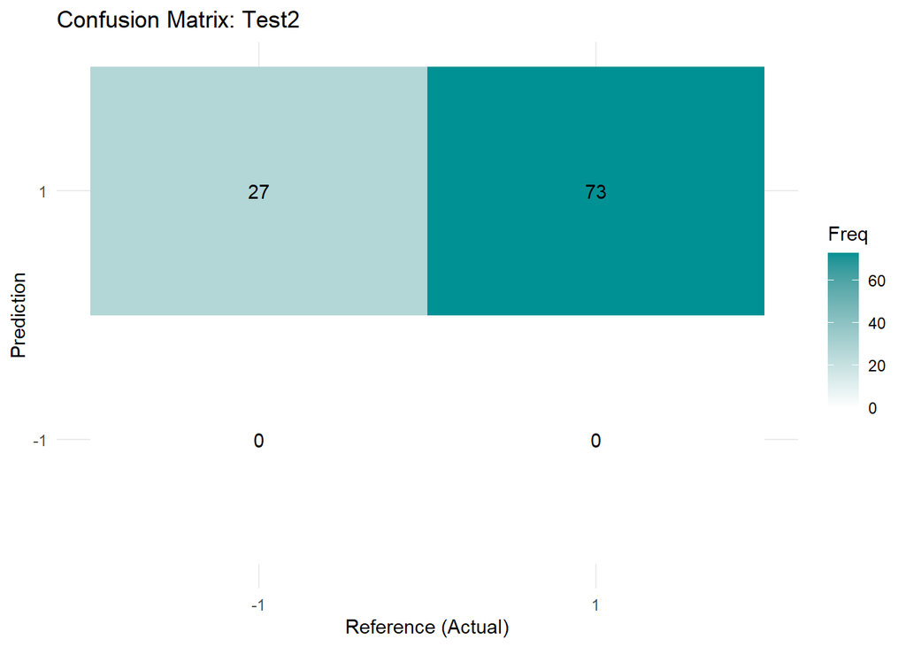

Figure: Visualization of data.

# Section 6 Discussion and conclusion

# Acknowledgement

In this report, for section3 and section5, I used the code from Chatgpt, and the rest of the code is from TA’s project discussion.

## Appendix: Code Implementation

```
suppressWarnings(library(tidyverse))
suppressWarnings(library(knitr))
suppressWarnings(library(dplyr))
library(caret)
```

```
library(ROCR)
```

```
# Load the data
session=list()
for(i in 1:18){
  session[[1]]=readRDS("C:/Users/28362/Downloads/sessions/session1.rds")
  session[[2]]=readRDS("C:/Users/28362/Downloads/sessions/session2.rds")
  session[[3]]=readRDS("C:/Users/28362/Downloads/sessions/session3.rds")
  session[[4]]=readRDS("C:/Users/28362/Downloads/sessions/session4.rds")
  session[[5]]=readRDS("C:/Users/28362/Downloads/sessions/session5.rds")
  session[[6]]=readRDS("C:/Users/28362/Downloads/sessions/session6.rds")
  session[[7]]=readRDS("C:/Users/28362/Downloads/sessions/session7.rds")
  session[[8]]=readRDS("C:/Users/28362/Downloads/sessions/session8.rds")
  session[[9]]=readRDS("C:/Users/28362/Downloads/sessions/session9.rds")
  session[[10]]=readRDS("C:/Users/28362/Downloads/sessions/session10.rds")
  session[[11]]=readRDS("C:/Users/28362/Downloads/sessions/session11.rds")
  session[[12]]=readRDS("C:/Users/28362/Downloads/sessions/session12.rds")
  session[[13]]=readRDS("C:/Users/28362/Downloads/sessions/session13.rds")
  session[[14]]=readRDS("C:/Users/28362/Downloads/sessions/session14.rds")
  session[[15]]=readRDS("C:/Users/28362/Downloads/sessions/session15.rds")
  session[[16]]=readRDS("C:/Users/28362/Downloads/sessions/session16.rds")
  session[[17]]=readRDS("C:/Users/28362/Downloads/sessions/session17.rds")
  session[[18]]=readRDS("C:/Users/28362/Downloads/sessions/session18.rds")
}
# Here I create an empty list called 'session' to store data for multiple sessions.
# I use a list because each session can be treated as a separate data set, and storing them in a list allows for easy iteration or merging later on.
```

```
n.session=length(session)
meta <- tibble(
  mouse_name = rep('name',n.session),
  date_exp =rep('dt',n.session),
  n_brain_area = rep(0,n.session),
  n_neurons = rep(0,n.session),
  n_trials = rep(0,n.session),
  success_rate = rep(0,n.session)
)
for(i in 1:n.session){
  tmp = session[[i]];
  meta[i,1]=tmp$mouse_name;
  meta[i,2]=tmp$date_exp;
  meta[i,3]=length(unique(tmp$brain_area));
  meta[i,4]=dim(tmp$spks[[1]])[1];
  meta[i,5]=length(tmp$feedback_type);
  meta[i,6]=mean(tmp$feedback_type+1)/2;
  }
kable(meta, format = "html", table.attr = "class='table table-striped'",digits=2)
```

```
#calculates the average spike count per brain area for a specific trial within a selected session.
i.s=2
i.t=1
spk.trial = session[[i.s]]$spks[[i.t]]
area=session[[i.s]]$brain_area
spk.count=apply(spk.trial,1,sum)
spk.average.tapply=tapply(spk.count, area, mean)
tmp <- data.frame(
  area = area,
  spikes = spk.count
)
spk.average.dplyr =tmp %>%
  group_by(area) %>%
  summarize(mean= mean(spikes))
```

```
#calculates the average spike count per brain area for a given trial in a session.The average spike count per brain area could be used as an input feature in a predictive model.
average_spike_area<-function(i.t,this_session){
  spk.trial = this_session$spks[[i.t]]
  area= this_session$brain_area
  spk.count=apply(spk.trial,1,sum)
  spk.average.tapply=tapply(spk.count, area, mean)
  return(spk.average.tapply)
  }
average_spike_area(1,this_session = session[[i.s]])
```

```
##      CA1     POST     root     VISl    VISpm
## 1.121053 1.816754 1.538462 1.398268 2.000000
```

```
#This R code constructs a trial-level summary data set for a given session, capturing neural activity per brain area along with task-related variables (feedback type and stimulus contrast levels).
n.trial=length(session[[i.s]]$feedback_type)
n.area=length(unique(session[[i.s]]$brain_area ))
trial.summary =matrix(nrow=n.trial,ncol= n.area+1+2+1)
for(i.t in 1:n.trial){
  trial.summary[i.t,]=c(average_spike_area(i.t,this_session = session[[i.s]]),
                          session[[i.s]]$feedback_type[i.t],
                        session[[i.s]]$contrast_left[i.t],
                        session[[i.s]]$contrast_right[i.s],
                        i.t)
}
colnames(trial.summary)=c(names(average_spike_area(i.t,this_session = session[[i.s]])), 'feedback', 'left contr.','right contr.','id' )
trial.summary <- as_tibble(trial.summary)
```

```
area.col=rainbow(n=n.area,alpha=0.7)
plot(x=1,y=0, col='white',xlim=c(0,n.trial),ylim=c(0.5,2.2), xlab="Trials",ylab="Average spike counts", main=paste("Spikes per area in Session", i.s))
for(i in 1:n.area){
  lines(y=trial.summary[[i]],x=trial.summary$id,col=area.col[i],lty=2,lwd=1)
  lines(smooth.spline(trial.summary$id, trial.summary[[i]]),col=area.col[i],lwd=3)
  }
legend("topright",
  legend = colnames(trial.summary)[1:n.area],
  col = area.col,
  lty = 1,
  cex = 0.8
)
```

```
#visualizes spike activity across neurons in a single trial, showing when each neuron fired during the trial.
plot.trial<-function(i.t,area, area.col,this_session){

    spks=this_session$spks[[i.t]];
    n.neuron=dim(spks)[1]
    time.points=this_session$time[[i.t]]

    plot(0,0,xlim=c(min(time.points),max(time.points)),ylim=c(0,n.neuron+1),col='white', xlab='Time (s)',yaxt='n', ylab='Neuron', main=paste('Trial ',i.t, 'feedback', this_session$feedback_type[i.t] ),cex.lab=1.5)
    for(i in 1:n.neuron){
        i.a=which(area== this_session$brain_area[i]);
        col.this=area.col[i.a]

        ids.spike=which(spks[i,]>0) # find out when there are spikes
        if( length(ids.spike)>0 ){
            points(x=time.points[ids.spike],y=rep(i, length(ids.spike) ),pch='.',cex=2, col=col.this)
        }


    }

legend("topright",
  legend = area,
  col = area.col,
  pch = 16,
  cex = 0.8
  )
  }
```

```
varname=names(trial.summary);
area=varname[1:(length(varname)-4)]
plot.trial(1,area, area.col,session[[i.s]])
```

```
varname=names(trial.summary);
area=varname[1:(length(varname)-4)]
par(mfrow=c(1,2))
plot.trial(1,area, area.col,session[[i.s]])
plot.trial(2,area, area.col,session[[i.s]])
```

```
par(mfrow=c(1,1))
```

```
session <- list.files(path = "C:\\Users\\28362\\Downloads\\sessions", pattern = "session\\d+\\.rds", full.names = TRUE)
all_sessions <- lapply(session, readRDS)
all_data <- list()
for (i in seq_along(all_sessions)) {
  session <- all_sessions[[i]]
  if (!all(c("contrast_left", "contrast_right", "feedback_type", "mouse_name", "spks") %in% names(session))) {
    next
  }
  contrast_difference <- session$contrast_left - session$contrast_right
  avg_spike_rate <- sapply(session$spks, function(spk) ifelse(is.null(spk), NA, mean(spk, na.rm = TRUE)))
  session_df <- data.frame(
    session_num = i,
    mouse_name = session$mouse_name,
    contrast_difference = contrast_difference,
    feedback_type = session$feedback_type,
    avg_spike_rate = avg_spike_rate
  )

  all_data[[i]] <- session_df
}
final_dataset <- bind_rows(all_data)
final_dataset <- na.omit(final_dataset)
final_dataset$session_num <- as.factor(final_dataset$session_num)
final_dataset$mouse_name <- as.factor(final_dataset$mouse_name)
str(final_dataset)
```

```
## 'data.frame':    5081 obs. of  5 variables:
##  $ session_num        : Factor w/ 18 levels "1","2","3","4",..: 1 1 1 1 1 1 1 1 1 1 ...
##  $ mouse_name         : Factor w/ 4 levels "Cori","Forssmann",..: 1 1 1 1 1 1 1 1 1 1 ...
##  $ contrast_difference: num  -0.5 0 -0.5 0 0 0 0.5 0.5 0 0.25 ...
##  $ feedback_type      : num  1 1 -1 -1 -1 1 1 1 1 1 ...
##  $ avg_spike_rate     : num  0.0395 0.0328 0.0461 0.0345 0.0356 ...
```

```
head(final_dataset)
```

```
##   session_num mouse_name contrast_difference feedback_type avg_spike_rate
## 1           1       Cori                -0.5             1     0.03954360
## 2           1       Cori                 0.0             1     0.03279973
## 3           1       Cori                -0.5            -1     0.04611717
## 4           1       Cori                 0.0            -1     0.03453678
## 5           1       Cori                 0.0            -1     0.03562670
## 6           1       Cori                 0.0             1     0.02735014
```

```
library(DT)
```

```
datatable(final_dataset, options = list(pageLength = 10, autoWidth = TRUE),
          caption = "Table: Summary of Final Dataset")
```

```
library(ggplot2)
library(dplyr)
session <- list.files(path = "C:\\Users\\28362\\Downloads\\sessions", pattern = "session\\d+\\.rds", full.names = TRUE)
all_sessions <- lapply(session, readRDS)
all_data <- list()
for (i in seq_along(all_sessions)) {
  session <- all_sessions[[i]]
  if (!all(c("contrast_left", "contrast_right", "feedback_type", "mouse_name", "spks") %in% names(session))) {
    next
  }
  contrast_difference <- session$contrast_left - session$contrast_right
  avg_spike_rate <- sapply(session$spks, function(spk) ifelse(is.null(spk), NA, mean(spk, na.rm = TRUE)))
  session_df <- data.frame(
    session_num = i,
    mouse_name = session$mouse_name,
    contrast_difference = contrast_difference,
    feedback_type = session$feedback_type,
    avg_spike_rate = avg_spike_rate
  )
  all_data[[i]] <- session_df
}
final_dataset <- bind_rows(all_data)
final_dataset <- na.omit(final_dataset)  # 去除缺失值
final_dataset$session_num <- as.factor(final_dataset$session_num)
final_dataset$mouse_name <- as.factor(final_dataset$mouse_name)
final_dataset$avg_spike_rate <- log1p(final_dataset$avg_spike_rate)  # log(1 + x) 避免 log(0) 问题
pca_data <- final_dataset %>%
  select(avg_spike_rate,contrast_difference,feedback_type)  # 选择数值列
pca_result <- prcomp(pca_data, center = TRUE, scale. = TRUE)  # 标准化并计算 PCA
pca_scores <- as.data.frame(pca_result$x)
final_dataset <- cbind(final_dataset, pca_scores)
ggplot(final_dataset, aes(x = PC1, y = PC2, color = session_num)) +
  geom_jitter(width = 0.1, height = 0.1, alpha = 0.6) +  # 加入抖动，防止数据重叠
  labs(title = "PCA: PC1 vs PC2", color = "session_id") +
  theme_minimal()
```

```
ggplot(final_dataset, aes(x = PC1, y = PC2, color = mouse_name)) +
  geom_jitter(width = 0.1, height = 0.1, alpha = 0.6) +  # 加入抖动
  labs(title = "PCA: PC1 vs PC2", color = "mouse_name") +
  theme_minimal()
```

```
session <- list()
for(i in 1:18){
  session[[i]] <- readRDS(paste0("C:/Users/28362/Downloads/sessions/session", i, ".rds"))
}
#Trial-Level Decision and Neural Activity Data for Session 18
n_obs = length(session[[18]]$feedback_type)


# Create a tibble to store trial-level data for the session
  dat = tibble(
    feedback_type = as.factor(session[[18]]$feedback_type),
    decision = rep('name', n_obs),
    avg_spikes = rep(0, n_obs)
  )

# Loop through each trial to compute decision category
  for (i in 1:n_obs){
      # decision
      if (session[[18]]$contrast_left[i] > session[[18]]$contrast_right[i]){
        dat$decision[i] = '1'
      } else if (session[[18]]$contrast_left[i] < session[[18]]$contrast_right[i]){
        dat$decision[i] = '2'
      } else if (session[[18]]$contrast_left[i] == session[[18]]$contrast_right[i]
               & session[[18]]$contrast_left[i] == 0){
        dat$decision[i] = '3'
      } else{
        dat$decision[i] = '4'
    }

    # avg_spks
    spks.trial = session[[18]]$spks[[i]]
    total.spikes = apply(spks.trial, 1, sum)
    dat$avg_spikes[i] = mean(total.spikes)
}

dat$decision = as.factor(dat$decision)
summary(dat)
```

```
##  feedback_type decision   avg_spikes
##  -1: 42        1:72     Min.   :0.6872
##  1 :174        2:71     1st Qu.:1.0055
##                3:63     Median :1.1050
##                4:10     Mean   :1.0964
##                         3rd Qu.:1.2060
##                         Max.   :1.5284
```

```
# Split data into train and test
set.seed(101)
sample <- sample.int(n = n_obs, size = floor(.8 * n_obs), replace = F)
train <- dat[sample, ]
test  <- dat[-sample, ]
```

```
fit1 <- glm(feedback_type~., data = train, family="binomial")
summary(fit1)
```

```
##
## Call:
## glm(formula = feedback_type ~ ., family = "binomial", data = train)
##
## Coefficients:
##             Estimate Std. Error z value Pr(>|z|)
## (Intercept)  -3.1945     1.5730  -2.031  0.04227 *
## decision2    -0.2750     0.6230  -0.441  0.65892
## decision3    -0.7646     0.5300  -1.443  0.14915
## decision4    -3.1867     0.8569  -3.719  0.00020 ***
## avg_spikes    4.9317     1.5257   3.232  0.00123 **
## ---
## Signif. codes:  0 '***' 0.001 '**' 0.01 '*' 0.05 '.' 0.1 ' ' 1
##
## (Dispersion parameter for binomial family taken to be 1)
##
##     Null deviance: 165.27  on 171  degrees of freedom
## Residual deviance: 137.34  on 167  degrees of freedom
## AIC: 147.34
##
## Number of Fisher Scoring iterations: 5
```

```
#evaluates the logistic regression model.
pred1 <- predict(fit1, test %>% select(-feedback_type), type = 'response')
prediction1 <- factor(pred1 > 0.5, labels = c('-1', '1'))
mean(prediction1 != test$feedback_type)
```

```
## [1] 0.2272727
```

```
cm <- confusionMatrix(prediction1, test$feedback_type, dnn = c("Prediction", "Reference"))

plt <- as.data.frame(cm$table)

ggplot(plt, aes(Reference, Prediction, fill= Freq)) +
        geom_tile() + geom_text(aes(label=Freq)) +
        scale_fill_gradient(low="white", high="#009194") +
        labs(x = "Reference",y = "Prediction") +
        scale_x_discrete(labels=c("-1","1")) +
        scale_y_discrete(labels=c("-1","1"))
```

```
#create a baseline model that always predicts "1" (successful trial) and evaluates its error rate.
prediction0 = factor(rep('1', nrow(test)), levels = c('1', '-1'))
mean(prediction0 != test$feedback_type)
```

```
## [1] 0.2272727
```

```
cm <- confusionMatrix(prediction0, test$feedback_type, dnn = c("Prediction", "Reference"))
```

```
plt <- as.data.frame(cm$table)

ggplot(plt, aes(Reference, Prediction, fill= Freq)) +
        geom_tile() + geom_text(aes(label=Freq)) +
        scale_fill_gradient(low="white", high="#009194") +
        labs(x = "Reference",y = "Prediction") +
        scale_x_discrete(labels=c("-1","1")) +
        scale_y_discrete(labels=c("-1","1"))
```

```
#This table summarizes the number of recorded neurons per brain area in Session 18.
table(session[[18]]$brain_area)
```

```
##
##  ACB  CA3   CP  LGd   OT root   SI  SNr   TH   ZI
##  155   35  158   89   26   99   48  130  175  175
```

```
#calculates the average spike rate for each brain area in a given trial.
average_spike_area<-function(i.t,this_session){
  spk.trial = this_session$spks[[i.t]]
  area= this_session$brain_area
  spk.count=apply(spk.trial,1,sum)
  spk.average.tapply=tapply(spk.count, area, mean)
  return(spk.average.tapply)
}
```

```
#neural activity data from different brain areas
n_area = length(unique(session[[18]]$brain_area))
spk_area = matrix(rep(0, n_obs * n_area), n_obs, n_area)
for (i in 1:n_obs){
    spk_area[i,] = average_spike_area(i, session[[18]])
}

spk_area = as_tibble(spk_area)
```

```
colnames(spk_area)= unique(session[[18]]$brain_area)
dat1 = bind_cols(dat, spk_area) %>% select(-avg_spikes)
head(dat1)
```

```
## # A tibble: 6 × 12
##   feedback_type decision    CP   ACB    OT    SI   SNr   LGd    ZI   CA3  root
##   <fct>         <fct>    <dbl> <dbl> <dbl> <dbl> <dbl> <dbl> <dbl> <dbl> <dbl>
## 1 1             1        1.27  1.63  1.13  0.787 0.846  2.08  1.85 0.8    1.06
## 2 1             1        1.16  1.4   1.12  1.04  0.577  1.86  2.19 1.06   1.41
## 3 -1            3        0.723 1.43  0.943 1.25  0.538  1.92  1.52 0.923  1.24
## 4 -1            3        0.890 0.829 0.652 1.16  0.423  1.65  1.81 0.815  1.02
## 5 1             3        0.729 1.26  0.582 0.989 0.346  2.36  1.67 0.885  1.36
## 6 1             1        0.981 1.43  0.810 0.719 0.808  1.94  1.96 0.823  1.25
## # ℹ 1 more variable: TH <dbl>
```

```
# Split data into train and test
set.seed(101)
sample <- sample.int(n = n_obs, size = floor(.8 * n_obs), replace = F)
train <- dat1[sample, ]
test  <- dat1[-sample, ]
```

```
fit2 <- glm(feedback_type~., data = train, family="binomial")
summary(fit2)
```

```
##
## Call:
## glm(formula = feedback_type ~ ., family = "binomial", data = train)
##
## Coefficients:
##             Estimate Std. Error z value Pr(>|z|)
## (Intercept)  -1.8890     2.2237  -0.849 0.395618
## decision2    -0.2538     0.7222  -0.351 0.725250
## decision3    -1.4426     0.6522  -2.212 0.026982 *
## decision4    -3.6987     0.9971  -3.710 0.000208 ***
## CP            3.7749     2.5070   1.506 0.132144
## ACB          -0.3608     0.6038  -0.598 0.550105
## OT            1.8254     2.1131   0.864 0.387668
## SI            1.5682     1.0881   1.441 0.149503
## SNr          -1.7827     0.9467  -1.883 0.059700 .
## LGd           2.2555     1.2566   1.795 0.072671 .
## ZI           -2.8712     1.1066  -2.595 0.009473 **
## CA3           2.5892     1.3209   1.960 0.049967 *
## root          1.5494     1.6697   0.928 0.353443
## TH           -3.3211     1.6903  -1.965 0.049441 *
## ---
## Signif. codes:  0 '***' 0.001 '**' 0.01 '*' 0.05 '.' 0.1 ' ' 1
##
## (Dispersion parameter for binomial family taken to be 1)
##
##     Null deviance: 165.27  on 171  degrees of freedom
## Residual deviance: 118.94  on 158  degrees of freedom
## AIC: 146.94
##
## Number of Fisher Scoring iterations: 6
```

```
pred2 <- predict(fit2, test %>% select(-feedback_type), type = 'response')
prediction2 <- factor(pred2 > 0.5, labels = c('-1', '1'))
mean(prediction2 != test$feedback_type)
```

```
## [1] 0.25
```

```
cm <- confusionMatrix(prediction2, test$feedback_type, dnn = c("Prediction", "Reference"))

plt <- as.data.frame(cm$table)

ggplot(plt, aes(Reference, Prediction, fill= Freq)) +
        geom_tile() + geom_text(aes(label=Freq)) +
        scale_fill_gradient(low="white", high="#009194") +
        labs(x = "Reference",y = "Prediction") +
        scale_x_discrete(labels=c("-1","1")) +
        scale_y_discrete(labels=c("-1","1"))
```

```
# Model 1
pr = prediction(pred1, test$feedback_type)
prf <- performance(pr, measure = "tpr", x.measure = "fpr")
auc <- performance(pr, measure = "auc")
auc <- auc@y.values[[1]]

# Model 2
pr = prediction(pred2, test$feedback_type)
prf2 <- performance(pr, measure = "tpr", x.measure = "fpr")
auc2 <- performance(pr, measure = "auc")
auc2 <- auc2@y.values[[1]]

# Bias Guess
pred0 = pred1 * 0 + 1
pr = prediction(pred0, test$feedback_type)
prf0 <- performance(pr, measure = "tpr", x.measure = "fpr")
auc0 <- performance(pr, measure = "auc")
auc0 <- auc0@y.values[[1]]

plot(prf2, ,col = 'red', main = 'ROC curve')
plot(prf, add = TRUE, col = 'blue')
plot(prf0, add = TRUE, col = 'green')
legend("bottomright", legend=c("Model 1", "Model 2", "Bias Guess"), col=c("blue", "red", 'green'), lty=1:1,
       cex=0.8)
```

```
# AUC
print(c(auc, auc2, auc0))
```

```
## [1] 0.6558824 0.6941176 0.5000000
```

```
library(caret)
library(randomForest)
```

```
test1 <- readRDS("C:/Users/28362/test1.rds")
test2 <- readRDS("C:/Users/28362/test2.rds")
test1$feedback_type <- factor(test1$feedback_type, levels = c("-1", "1"))
test2$feedback_type <- factor(test2$feedback_type, levels = c("-1", "1"))
```

```
test1_df <- data.frame(
  contrast_left  = test1$contrast_left,
  contrast_right = test1$contrast_right,
  feedback_type  = test1$feedback_type
)
```

```
test2_df <- data.frame(
  contrast_left  = test2$contrast_left,
  contrast_right = test2$contrast_right,
  feedback_type  = test2$feedback_type
)
```

```
fit2 <- glm(feedback_type ~ contrast_left + contrast_right,
            data = test1_df,
            family = "binomial")
```

```
pred_probs_test1 <- predict(
  fit2,
  newdata = test1_df %>% select(-feedback_type),
  type = "response"
)
pred_class_test1 <- ifelse(pred_probs_test1 > 0.5, "1", "-1")
pred_class_test1 <- factor(pred_class_test1, levels = c("1","-1"))
accuracy_test1 <- mean(pred_class_test1 == test1_df$feedback_type)
print(paste("Accuracy on test1:", accuracy_test1))
```

```
## [1] "Accuracy on test1: 0.72"
```

```
cm_test1 <- confusionMatrix(
  data      = pred_class_test1,
  reference = test1_df$feedback_type,
  dnn       = c("Prediction", "Reference")
)
```

```
print(cm_test1)
```

```
## Confusion Matrix and Statistics
##
##           Reference
## Prediction -1  1
##         -1  0  0
##         1  28 72
##
##                Accuracy : 0.72
##                  95% CI : (0.6213, 0.8052)
##     No Information Rate : 0.72
##     P-Value [Acc > NIR] : 0.5507
##
##                   Kappa : 0
##
##  Mcnemar's Test P-Value : 3.352e-07
##
##             Sensitivity : 0.00
##             Specificity : 1.00
##          Pos Pred Value :  NaN
##          Neg Pred Value : 0.72
##              Prevalence : 0.28
##          Detection Rate : 0.00
##    Detection Prevalence : 0.00
##       Balanced Accuracy : 0.50
##
##        'Positive' Class : -1
##
```

```
df_test1 <- as.data.frame(cm_test1$table)
plot_test1 <- ggplot(df_test1, aes(x = Reference, y = Prediction, fill = Freq)) +
  geom_tile() +
  geom_text(aes(label = Freq), color = "black") +
  scale_fill_gradient(low = "white", high = "#009194") +
  labs(
    title = "Confusion Matrix: Test1",
    x = "Reference (Actual)",
    y = "Prediction"
  ) +
  theme_minimal()
show(plot_test1)
```

```
pred_probs_test2 <- predict(
  fit2,
  newdata = test2_df %>% select(-feedback_type),
  type = "response"
)
pred_class_test2 <- ifelse(pred_probs_test2 > 0.5, "1", "-1")
pred_class_test2 <- factor(pred_class_test2, levels = c("1","-1"))
accuracy_test2 <- mean(pred_class_test2 == test2_df$feedback_type)
print(paste("Accuracy on test2:", accuracy_test2))
```

```
## [1] "Accuracy on test2: 0.73"
```

```
cm_test2 <- confusionMatrix(
  data      = pred_class_test2,
  reference = test2_df$feedback_type,
  dnn       = c("Prediction", "Reference")
)
```

```
print(cm_test2)
```

```
## Confusion Matrix and Statistics
##
##           Reference
## Prediction -1  1
##         -1  0  0
##         1  27 73
##
##                Accuracy : 0.73
##                  95% CI : (0.632, 0.8139)
##     No Information Rate : 0.73
##     P-Value [Acc > NIR] : 0.5516
##
##                   Kappa : 0
##
##  Mcnemar's Test P-Value : 5.624e-07
##
##             Sensitivity : 0.00
##             Specificity : 1.00
##          Pos Pred Value :  NaN
##          Neg Pred Value : 0.73
##              Prevalence : 0.27
##          Detection Rate : 0.00
##    Detection Prevalence : 0.00
##       Balanced Accuracy : 0.50
##
##        'Positive' Class : -1
##
```

```
df_test2 <- as.data.frame(cm_test2$table)
plot_test2 <- ggplot(df_test2, aes(x = Reference, y = Prediction, fill = Freq)) +
  geom_tile() +
  geom_text(aes(label = Freq), color = "black") +
  scale_fill_gradient(low = "white", high = "#009194") +
  labs(
    title = "Confusion Matrix: Test2",
    x = "Reference (Actual)",
    y = "Prediction"
  ) +
  theme_minimal()
show(plot_test2)
```